# Red Wine Quality Analysis by Marko Horvat

Some of the plots are redone wiht better settings

```
##  fixed.acidity    volatile.acidity  citric.acid     residual.sugar
##  Min.   : 4.600   Min.   :0.1200   Min.   :0.0000   Min.   :0.900
##  1st Qu.: 7.100   1st Qu.:0.3900   1st Qu.:0.0900   1st Qu.:1.900
##  Median : 7.900   Median :0.5200   Median :0.2400   Median :2.200
##  Mean   : 8.234   Mean   :0.5201   Mean   :0.2571   Mean   :2.264
##  3rd Qu.: 9.100   3rd Qu.:0.6300   3rd Qu.:0.4100   3rd Qu.:2.500
##  Max.   :13.200   Max.   :1.0100   Max.   :0.7600   Max.   :5.000
##    chlorides       free.sulfur.dioxide total.sulfur.dioxide
##  Min.   :0.01200   Min.   : 1.00       Min.   :  6.00
##  1st Qu.:0.06900   1st Qu.: 8.00       1st Qu.: 22.00
##  Median :0.07800   Median :13.00       Median : 36.00
##  Mean   :0.07843   Mean   :15.18       Mean   : 43.36
##  3rd Qu.:0.08700   3rd Qu.:21.00       3rd Qu.: 58.00
##  Max.   :0.12200   Max.   :43.00       Max.   :142.00
##     density             pH          sulphates         alcohol
##  Min.   :0.9901   Min.   :2.880   Min.   :0.3300   Min.   : 8.70
##  1st Qu.:0.9955   1st Qu.:3.220   1st Qu.:0.5500   1st Qu.: 9.50
##  Median :0.9966   Median :3.320   Median :0.6100   Median :10.20
##  Mean   :0.9966   Mean   :3.322   Mean   :0.6373   Mean   :10.45
##  3rd Qu.:0.9976   3rd Qu.:3.410   3rd Qu.:0.7100   3rd Qu.:11.10
##  Max.   :1.0021   Max.   :4.010   Max.   :1.1300   Max.   :14.00
##     quality
##  Min.   :3.00
##  1st Qu.:5.00
##  Median :6.00
##  Mean   :5.66
##  3rd Qu.:6.00
##  Max.   :8.00
```

```
## 'data.frame':    1357 obs. of  12 variables:
##  $ fixed.acidity       : num  7.4 7.8 7.8 11.2 7.4 7.4 7.9 7.3 7.8 6.7 ...
##  $ volatile.acidity    : num  0.7 0.88 0.76 0.28 0.7 0.66 0.6 0.65 0.58 0.58 ...
##  $ citric.acid         : num  0 0 0.04 0.56 0 0 0.06 0 0.02 0.08 ...
##  $ residual.sugar      : num  1.9 2.6 2.3 1.9 1.9 1.8 1.6 1.2 2 1.8 ...
##  $ chlorides           : num  0.076 0.098 0.092 0.075 0.076 0.075 0.069 0.065 0.073 0.097 ...
##  $ free.sulfur.dioxide : num  11 25 15 17 11 13 15 15 9 15 ...
##  $ total.sulfur.dioxide: num  34 67 54 60 34 40 59 21 18 65 ...
##  $ density             : num  0.998 0.997 0.997 0.998 0.998 ...
##  $ pH                  : num  3.51 3.2 3.26 3.16 3.51 3.51 3.3 3.39 3.36 3.28 ...
##  $ sulphates           : num  0.56 0.68 0.65 0.58 0.56 0.56 0.46 0.47 0.57 0.54 ...
##  $ alcohol             : num  9.4 9.8 9.8 9.8 9.4 9.4 9.4 10 9.5 9.2 ...
##  $ quality             : int  5 5 5 6 5 5 5 7 7 5 ...
```

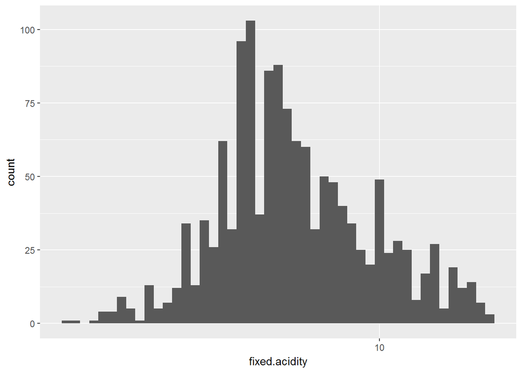

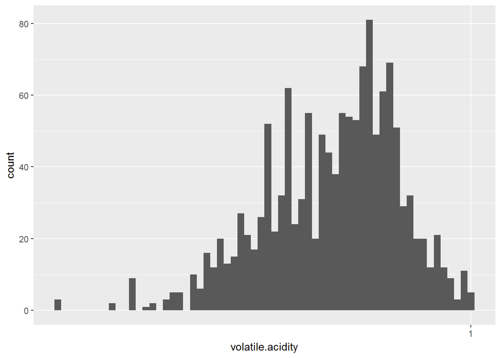

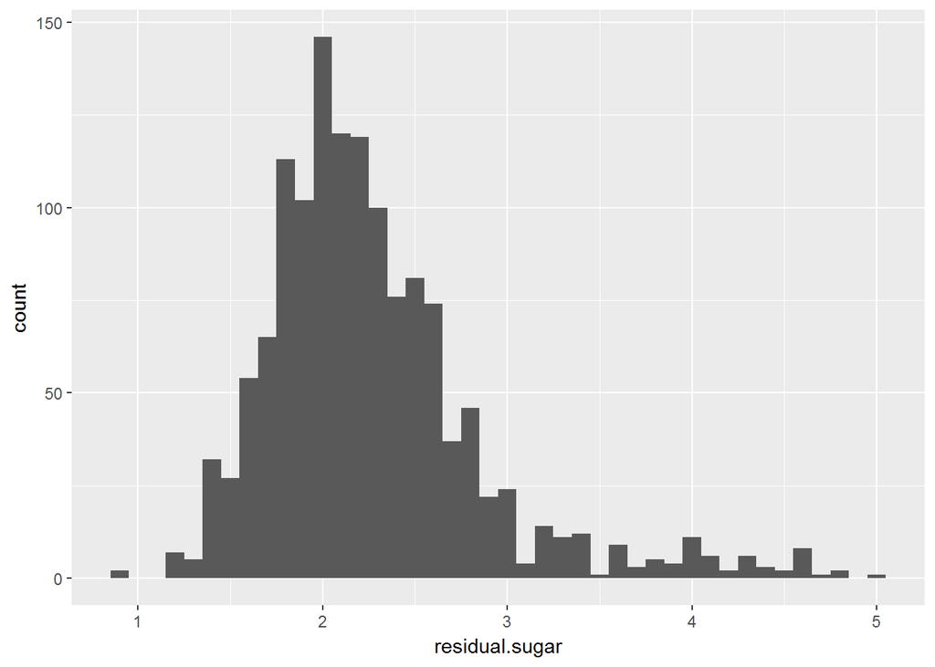

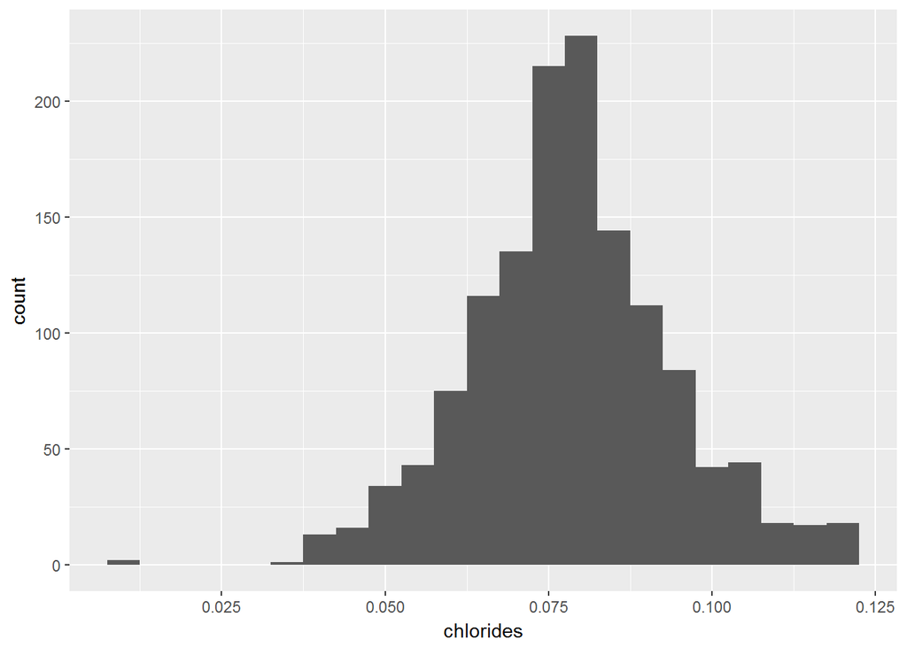

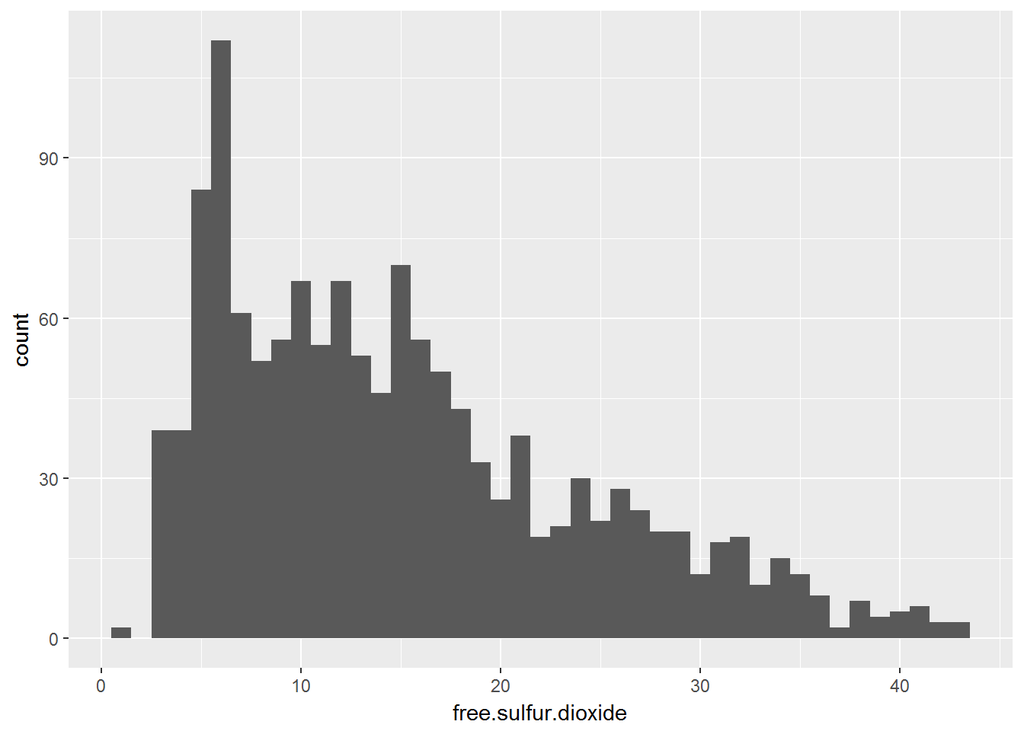

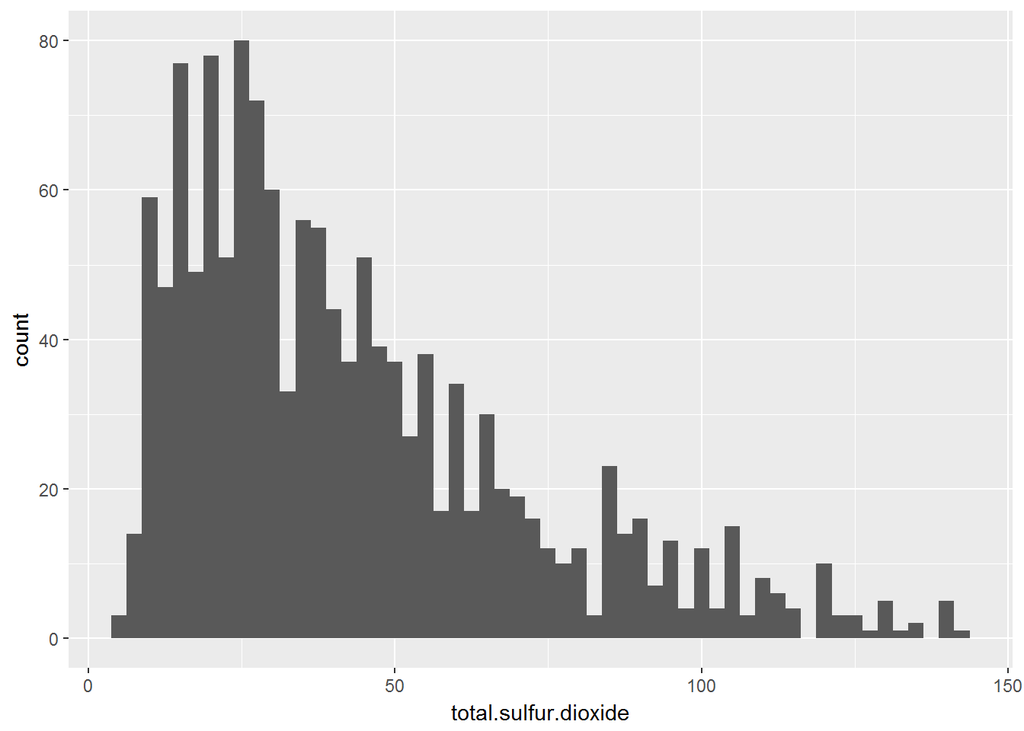

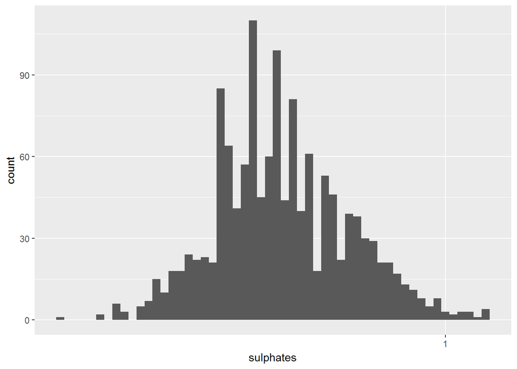

# Univariate Analysis

### What is/are the main feature(s) of interest in your dataset?

The main interest of this analysis is to determine which chemical properties influence the quality of red wines.

### What other features in the dataset do you think will help support your investigation into your feature(s) of interest?

Some of the independent variables could have strong correlation to eacher other but not to quality. This need to be investigated.

### Did you create any new variables from existing variables in the dataset?

No, I did not.

### Of the features you investigated, were there any unusual distributions? Did you perform any operations on the data to tidy, adjust, or change the form of the data? If so, why did you do this?

# Bivariate Plots Section

First, we will look at correlations between all variablas and based on calculated correlations I will explore strongest correlations among them.

```
##                      fixed.acidity volatile.acidity citric.acid
## fixed.acidity                1.000           -0.279       0.689
## volatile.acidity            -0.279            1.000      -0.597
## citric.acid                  0.689           -0.597       1.000
## residual.sugar               0.232            0.038       0.171
## chlorides                    0.245            0.109       0.114
## free.sulfur.dioxide         -0.170           -0.010      -0.084
## total.sulfur.dioxide        -0.115            0.097      -0.006
## density                      0.661            0.034       0.349
## pH                          -0.703            0.231      -0.504
## sulphates                    0.185           -0.334       0.268
## alcohol                     -0.088           -0.230       0.121
## quality                      0.097           -0.367       0.228
##                      residual.sugar chlorides free.sulfur.dioxide
## fixed.acidity                 0.232     0.245              -0.170
## volatile.acidity              0.038     0.109              -0.010
## citric.acid                   0.171     0.114              -0.084
## residual.sugar                1.000     0.259               0.022
## chlorides                     0.259     1.000              -0.013
## free.sulfur.dioxide           0.022    -0.013               1.000
## total.sulfur.dioxide          0.101     0.120               0.656
## density                       0.356     0.458              -0.080
## pH                           -0.084    -0.227               0.097
## sulphates                     0.019    -0.059               0.042
## alcohol                       0.098    -0.310              -0.038
## quality                       0.005    -0.185              -0.028
##                      total.sulfur.dioxide density     pH sulphates alcohol
## fixed.acidity                      -0.115   0.661 -0.703     0.185  -0.088
## volatile.acidity                    0.097   0.034  0.231    -0.334  -0.230
## citric.acid                        -0.006   0.349 -0.504     0.268   0.121
## residual.sugar                      0.101   0.356 -0.084     0.019   0.098
## chlorides                           0.120   0.458 -0.227    -0.059  -0.310
## free.sulfur.dioxide                 0.656  -0.080  0.097     0.042  -0.038
## total.sulfur.dioxide                1.000   0.069 -0.004    -0.073  -0.214
## density                             0.069   1.000 -0.310     0.102  -0.545
## pH                                 -0.004  -0.310  1.000     0.006   0.198
## sulphates                          -0.073   0.102  0.006     1.000   0.253
## alcohol                            -0.214  -0.545  0.198     0.253   1.000
## quality                            -0.201  -0.228 -0.037     0.410   0.512
##                      quality
## fixed.acidity          0.097
## volatile.acidity      -0.367
## citric.acid            0.228
## residual.sugar         0.005
## chlorides             -0.185
## free.sulfur.dioxide   -0.028
## total.sulfur.dioxide  -0.201
## density               -0.228
## pH                    -0.037
## sulphates              0.410
## alcohol                0.512
## quality                1.000
```

The independent variables show none to moderate correlations with the dependent variable quality. The variable having the highest correlation of 0.512 with quality is alcohol.

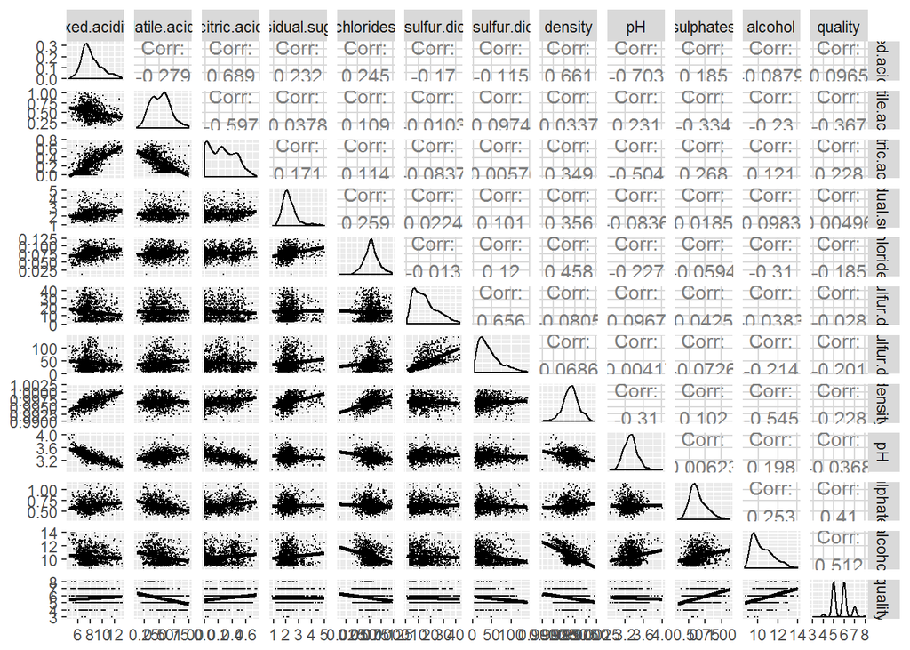

Since the objective of this analysis is to explore which chemical components have influence in red wines quality, three of the strongest positive and one negative correlations are explired and ploted.

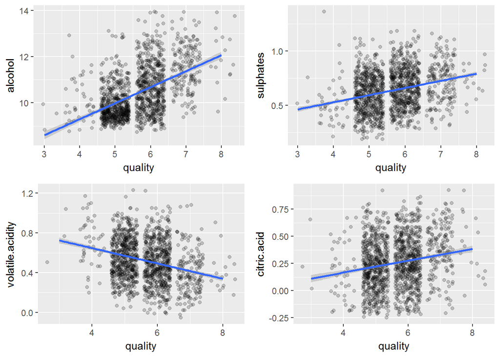

alcohol and quality have a strong positive correlation of 0.512 sulphates and quality have a strong positive correlation of 0.410 citric.acid and quality have a low positive correlation of 0.228  
volatile.acidity and quality have a mild negative correlation of -0.367

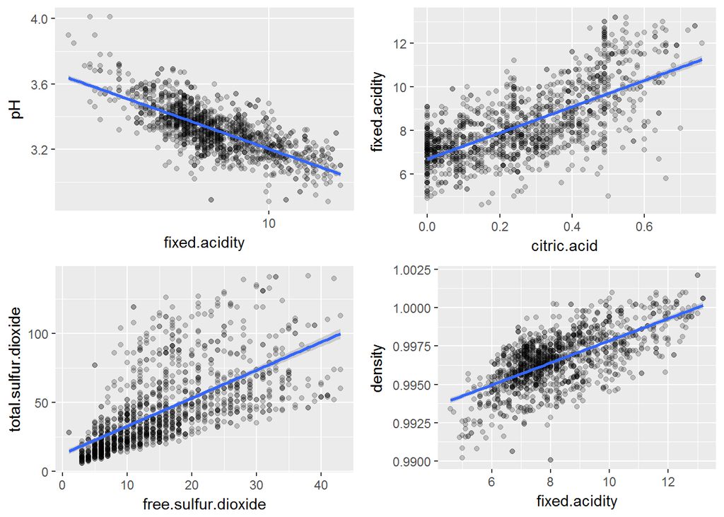

pH and fixed.acidity have a strong negtive correlation of -0.703 fixed.acidity and citric.acid have a strong positive correlation of 0.689 total.sulfur.dioxide and free.sulfur.dioxide have a strong positive correlation of 0.656 density and fixed.acidity also have a strong positive correlation of 0.661

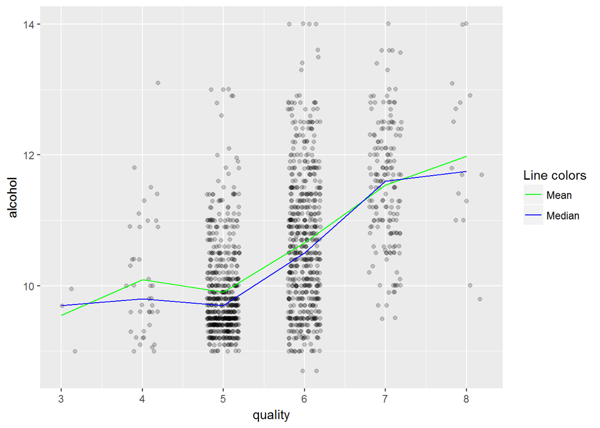

```r
ggplot(data=wqr, aes(x=quality,y=alcohol)) +
geom_jitter(alpha = 0.2, color = "black",
            position = position_jitter(width = .2)) +
geom_line(aes(colour = "Mean"), stat = "summary", fun.y = mean) +
geom_line(aes(colour = "Median"), stat = "summary", fun.y = median) +
  scale_colour_manual("Line colors", values = c("green", "blue"))
```

# Bivariate Analysis

### Talk about some of the relationships you observed in this part of the investigation. How did the feature(s) of interest vary with other features in the dataset?

Correlation between dependant and independent variables: alcohol and quality have a strong positive correlation of 0.512 sulphates and quality have a strong positive correlation of 0.410 citric.acid and quality have a low positive correlation of 0.228  
volatile.acidity and quality have a mild negative correlation of -0.367

Correlations between independent variables: pH and fixed.acidity have a strong negative correlation of -0.703 fixed.acidity and citric.acid have a strong positive correlation of 0.689 total.sulfur.dioxide and free.sulfur.dioxide have a strong positive correlation of 0.656 density and fixed.acidity also have a strong positive correlation of 0.661

### Did you observe any interesting relationships between the other features (not the main feature(s) of interest)?

There are strongcorrelations between pH and fixed.acidity, fixed.acidity and citric.acid, total.sulfur.dioxide and free.sulfur.dioxide & density and fixed.acidity

### What was the strongest relationship you found?

alcohol and quality have the strongest correlation between independent and dependent variables, while pH and fixed.acidity have the strongest interior correlation among independent variables.

# Multivariate Plots Section

We will analyse all the combinations of the most promising variables facet wiht quality. Variables: alcohol,sulphates, citric.acid & volatile.acidity. Those varibles have best correlation factor when compared against quality.

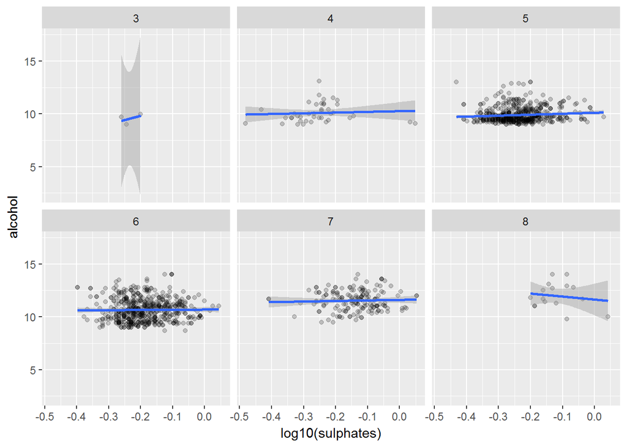

Sulphates & alcohol variables facet wiht quality

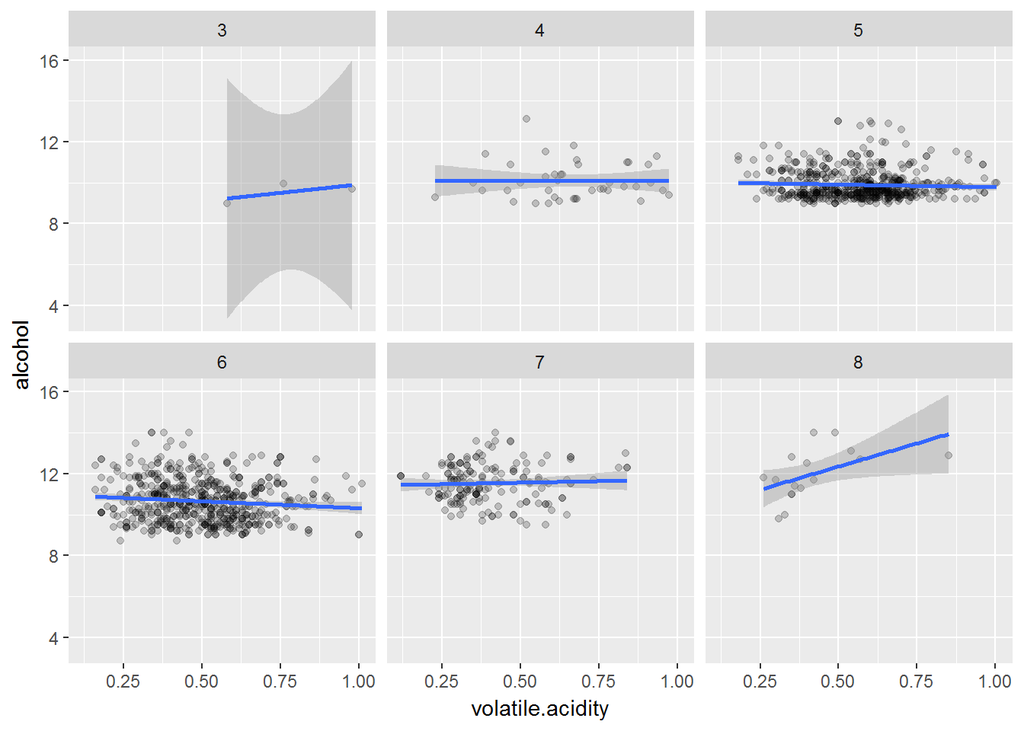

volatile.acidity & alcohol variables facet wiht quality

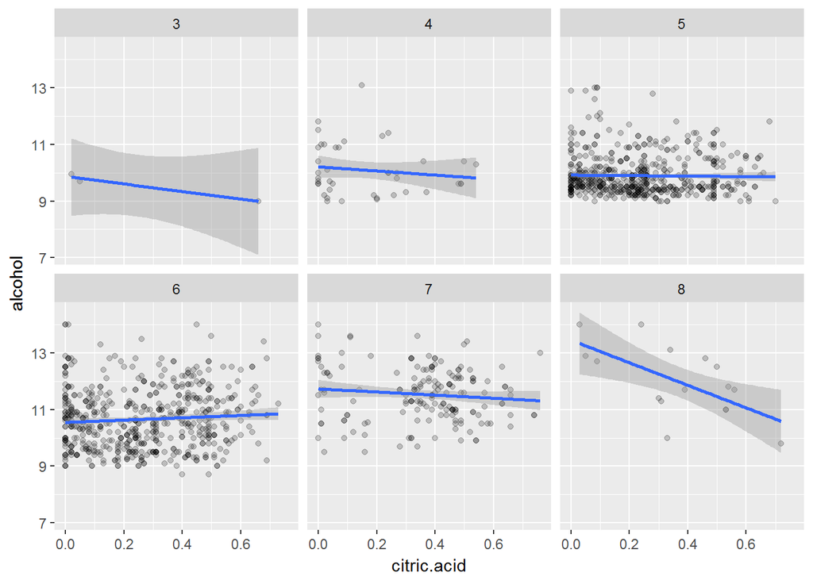

citric.acid & alcohol variables facet wiht quality

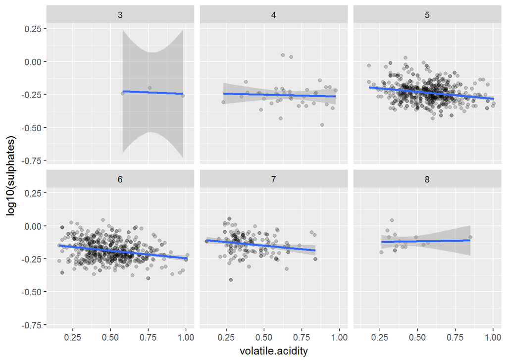

volatile.acidity & sulphates variables facet wiht quality

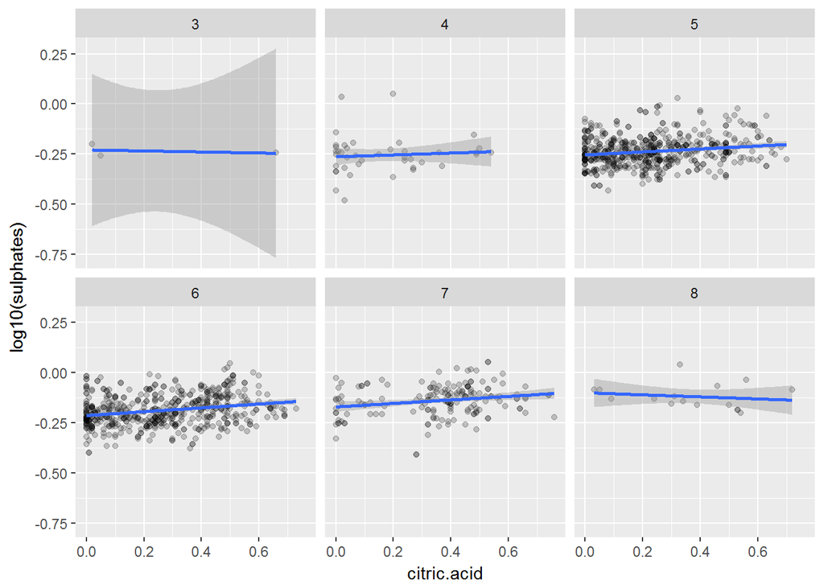

citric.acid & sulphates variables facet wiht quality

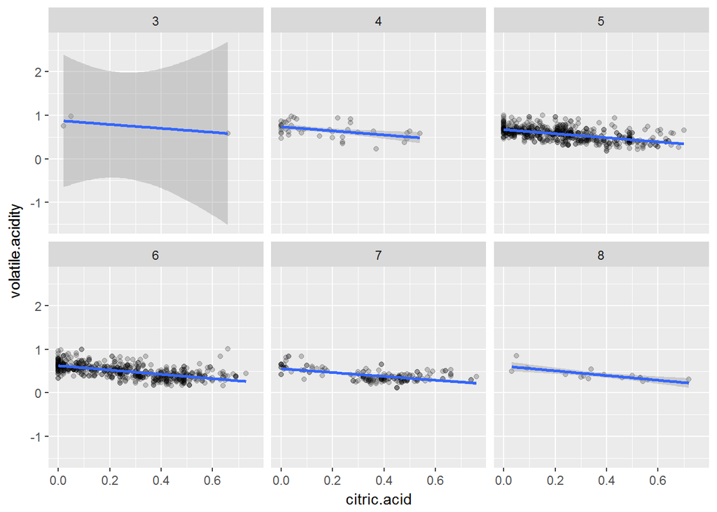

citric.acid & volatile.acidity variables facet wiht quality

## Linear Model

Linear model created from four major variables: alcohol, sulphates, citric acid, and volatile acidity. These were all compared to quality.

```
##
## Calls:
## m1: lm(formula = as.numeric(quality) ~ alcohol, data = wqr)
## m2: lm(formula = as.numeric(quality) ~ alcohol + sulphates, data = wqr)
## m3: lm(formula = as.numeric(quality) ~ alcohol + sulphates + volatile.acidity,
##     data = wqr)
## m4: lm(formula = as.numeric(quality) ~ alcohol + sulphates + volatile.acidity +
##     citric.acid, data = wqr)
##
## ============================================================================
##                          m1            m2            m3            m4
## ----------------------------------------------------------------------------
##   (Intercept)           1.714***      1.111***      2.044***      2.050***
##                        (0.181)       (0.176)       (0.205)       (0.215)
##   alcohol               0.378***      0.322***      0.300***      0.300***
##                        (0.017)       (0.017)       (0.017)       (0.017)
##   sulphates                           1.864***      1.510***      1.511***
##                                      (0.141)       (0.144)       (0.145)
##   volatile.acidity                                 -0.917***     -0.923***
##                                                    (0.109)       (0.132)
##   citric.acid                                                    -0.010
##                                                                  (0.113)
## ----------------------------------------------------------------------------
##   R-squared             0.262         0.346         0.378         0.378
##   adj. R-squared        0.261         0.345         0.377         0.376
##   sigma                 0.674         0.635         0.619         0.620
##   F                   480.497       357.747       274.100       205.426
##   p                     0.000         0.000         0.000         0.000
##   Log-likelihood    -1389.589     -1307.676     -1273.343     -1273.340
##   Deviance            615.963       545.913       518.976       518.973
##   AIC                2785.179      2623.352      2556.687      2558.679
##   BIC                2800.818      2644.204      2582.752      2589.958
##   N                  1357          1357          1357          1357
## ============================================================================
```

Linear model using four of the variables: alcohol, sulphates, volatile acidity & citric acid. R-squared for first three variables is 0.378 and was not changed with forth variable.

# Multivariate Analysis

### Talk about some of the relationships you observed in this part of the investigation. Were there features that strengthened each other in terms of looking at your feature(s) of interest?

Within all independent variables alcohol shows biggest correlation but still weak in correlations with the dependent variable of quality. Independent variables sulphates, volatile.acidity and citric.acid strengthen the correlations. Having a low sulphate count gave the alcohol lower quality. Lower quality wines tended to be lower in alcohol content and citric acid.

### OPTIONAL: Did you create any models with your dataset? Discuss the strengths and limitations of your model.

## I created a linear model using four of the variables: alcohol, sulphates, volatile acidity & citric acid. R-squared for first three variables is 0.378 and was not changed with forth variable. I can conclude that linear model is not appropriate method since the R value is too low to be considered valid.

# Final Plots and Summary

### Plot One

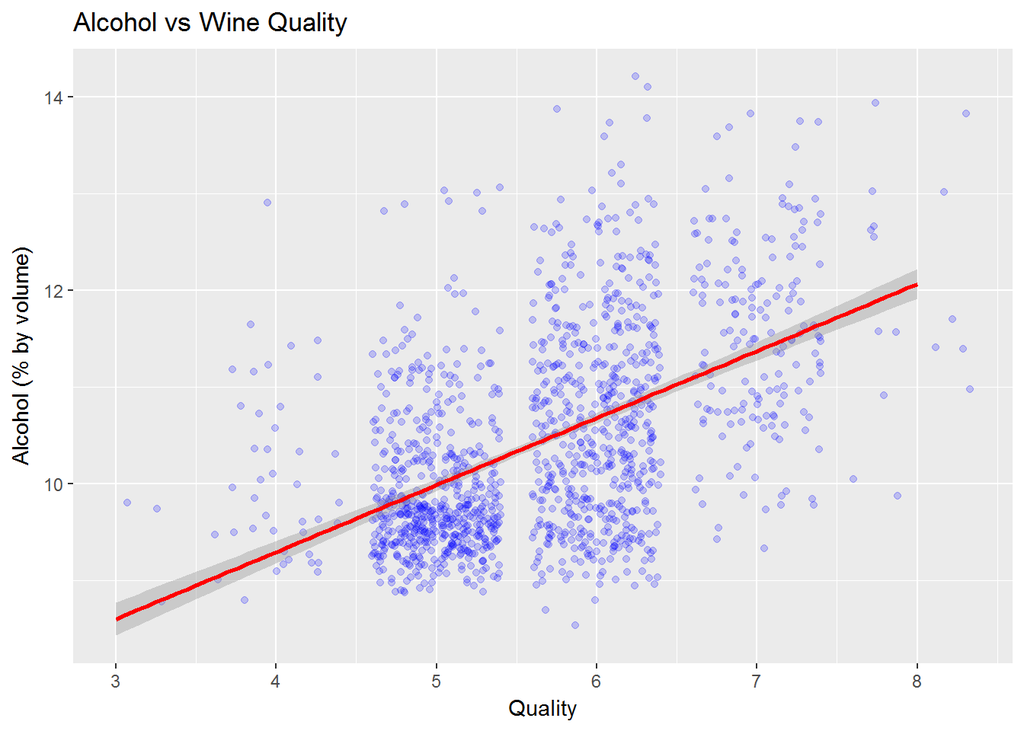

alcohol and quality have a strong positive correlation of 0.512. It can be seen from the plot that there is a linear correlation between those two variable.

### Plot Two

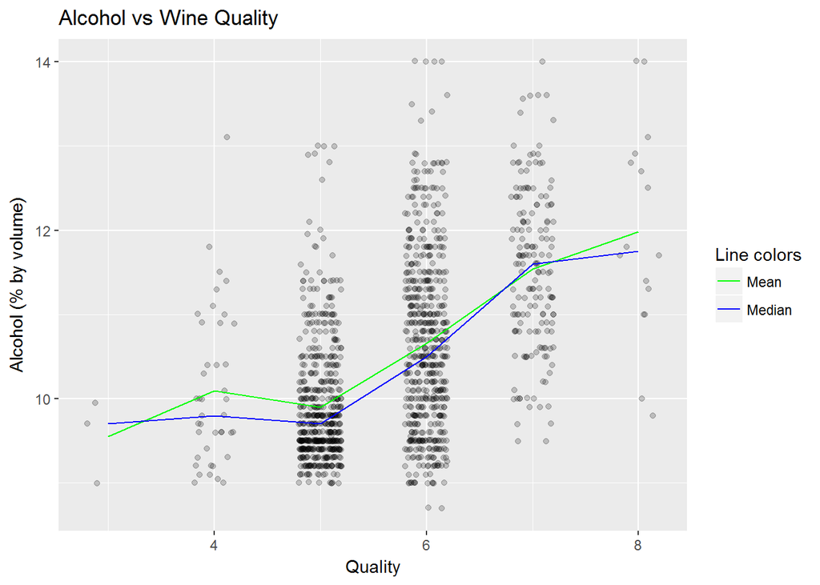

### Plot Three

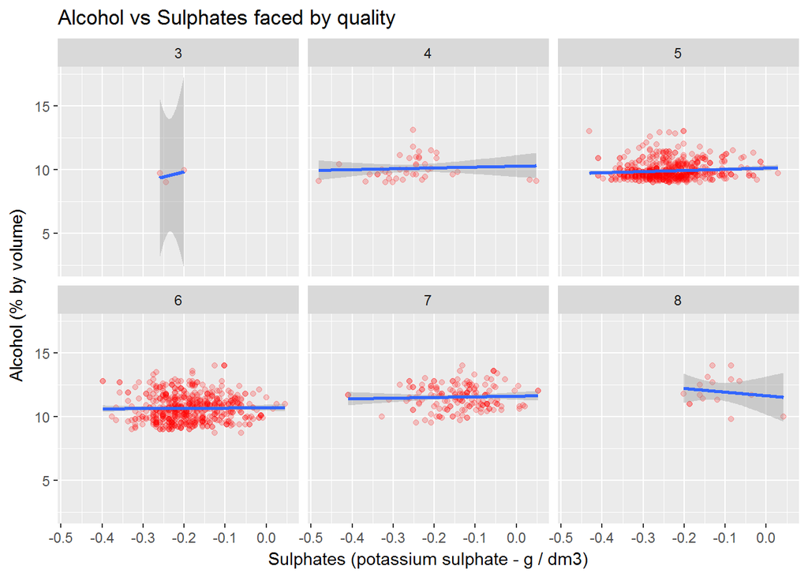

Sulphates & alcohol variables facet wiht quality. Within all independent variables alcohol shows biggest correlation but still weak in correlations with the dependent variable of quality. Independent variables sulphates strengthen the correlation.

# Reflection

In this red wine data analysis, I have explored main chemicals which determine the wine quality. It is obvious that chemicals are not the only factors that determine the wine scores but in this analysis we will limit ourselves only to exploring the chemicals.

Second part of analysis was about correlations between all variables. Furthermore the strongest correlations among them were explored.

Correlation between dependant and independent variables: alcohol and quality have a strong positive correlation of 0.512 sulphates and quality have a strong positive correlation of 0.410 citric.acid and quality have a low positive correlation of 0.228  
volatile.acidity and quality have a mild negative correlation of -0.367 Correlations between independent variables: pH and fixed.acidity have a strong negative correlation of -0.703 fixed.acidity and citric.acid have a strong positive correlation of 0.689 total.sulfur.dioxide and free.sulfur.dioxide have a strong positive correlation of 0.656 density and fixed.acidity also have a strong positive correlation of 0.661

Main chemical which have strongest correlation to quality is alcohol content. Alcohol variable itself is not sufficient but rather in combination with sulphates and acidity. The correlations for these variables are within reasonable bounds.

In multivariate analysis the linear model was created using four of the variables: alcohol, sulphates, volatile acidity & citric acid. R-squared for first three variables is 0.378 and was not changed with forth variable. Conclusion was that created linear model is not appropriate method since the R value is too low to be considered valid.

Furthermore, the weaknesses of this data is due to biases of the sommelier way of determining the quality not based on the chemicals. I assume that sommeliers always look for the same features and therefore the grades could be similar. Also I would assume that different sommeliers schools could possibly teach different techniques of wine grading. It would be nice to compare grades on same wines by sommeliers from different continents. Overall conclusion is that chemicals are not the only factor that have to be looked at when determine the quality at the wine.